# A1 - Preproceso de datos

## Javier Gómez de Diego

### 1. Carga del archivo

Leemos y cargamos el fichero, cuyos valores están separados por el carácter “**;**”

```r
d <- read.csv("train3.csv", sep=";")
```

Visualizamos también los primeros registros para ver el formato y tipo de los datos.

```r
head(d)
```

|  | ClaimNumber | DateTimeOfAccident | DateReported | Age | Gender | MaritalStatus | DependentChildren | DependentsOther | WeeklyWages | PartTimeFullTime | HoursWorkedPerWeek | DaysWorkedPerWeek | ClaimDescription | InitialIncurredCalimsCost | UltimateIncurredClaimCost |
| --- | --- | --- | --- | --- | --- | --- | --- | --- | --- | --- | --- | --- | --- | --- | --- |
| 1 | WC8285054 | 2002-04-09T07:00:00Z | 2002-07-05T00:00:00Z | 48 | M | M | 0 | 0 | 500 | F | 38 | 5 | LIFTING TYRE INJURY TO RIGHT ARM AND WRIST INJURY | 1500 | 4303.188001 |
| 2 | WC6982224 | 1999-01-07T11:00:00Z | 1999-01-20T00:00:00Z | 43 | F | m | 0 | 0 | 509,34 | F | 37,5 | 5 | STEPPED AROUND CRATES AND TRUCK TRAY FRACTURE LEFT FOREARM | 5500 | 6105.872938 |
| 3 | WC5481426 | 1996-03-25T00:00:00Z | 1996-04-14T00:00:00Z | 30 | M | U | 0 | 0 | 709,1 | F | 38 | 5 | CUT ON SHARP EDGE CUT LEFT THUMB | 1700 | 2098.629955 |
| 4 | WC9775968 | 2005-06-22T13:00:00Z | 2005-07-22T00:00:00Z | 41 | M | S | 0 | 0 | 555,46 | F | 38 | 5 | DIGGING LOWER BACK LOWER BACK STRAIN | 15000 | 16282.94081 |
| 5 | WC2634037 | 1990-08-29T08:00:00Z | 1990-09-27T00:00:00Z | 36 | M | M | 0 | 0 | 377,1 | F | 38 | 5 | REACHING ABOVE SHOULDER LEVEL ACUTE MUSCLE STRAIN LEFT SIDE OF STOMACH | 2800 | 3771.73258 |
| 6 | WC6828422 | 1999-06-21T11:00:00Z | 1999-09-09T00:00:00Z | 50 | M | M | 0 | 0 | 200 | F | 38 | 5 | STRUCK HEAD ON HEAD LACERATED HEAD | 500 | 746.6213097 |

Para profundizar más, obtenemos más información de cada variable.

```r
summary(d)
```

```
##  ClaimNumber        DateTimeOfAccident DateReported            Age
##  Length:54000       Length:54000       Length:54000       Min.   : 13.00
##  Class :character   Class :character   Class :character   1st Qu.: 23.00
##  Mode  :character   Mode  :character   Mode  :character   Median : 32.00
##                                                           Mean   : 34.06
##                                                           3rd Qu.: 43.00
##                                                           Max.   :999.00
##     Gender          MaritalStatus      DependentChildren DependentsOther
##  Length:54000       Length:54000       Min.   :0.0000    Min.   :0.000000
##  Class :character   Class :character   1st Qu.:0.0000    1st Qu.:0.000000
##  Mode  :character   Mode  :character   Median :0.0000    Median :0.000000
##                                        Mean   :0.1192    Mean   :0.009944
##                                        3rd Qu.:0.0000    3rd Qu.:0.000000
##                                        Max.   :9.0000    Max.   :5.000000
##  WeeklyWages        PartTimeFullTime   HoursWorkedPerWeek DaysWorkedPerWeek
##  Length:54000       Length:54000       Length:54000       Min.   :1.000
##  Class :character   Class :character   Class :character   1st Qu.:5.000
##  Mode  :character   Mode  :character   Mode  :character   Median :5.000
##                                                           Mean   :4.906
##                                                           3rd Qu.:5.000
##                                                           Max.   :7.000
##  ClaimDescription   InitialIncurredCalimsCost UltimateIncurredClaimCost
##  Length:54000       Min.   :      1           Length:54000
##  Class :character   1st Qu.:    700           Class :character
##  Mode  :character   Median :   2000           Mode  :character
##                     Mean   :   7841
##                     3rd Qu.:   9500
##                     Max.   :2000000
```

### 2. Duplicación de códigos

Realizamos la búsqueda de los registros cuyo *ClaimNumber* ya haya aparecido anteriormente.

```r
d[which(duplicated(d$ClaimNumber)), ]
```

|  | ClaimNumber | DateTimeOfAccident | DateReported | Age | Gender | MaritalStatus | DependentChildren | DependentsOther | WeeklyWages | PartTimeFullTime | HoursWorkedPerWeek | DaysWorkedPerWeek | ClaimDescription | InitialIncurredCalimsCost | UltimateIncurredClaimCost |
| --- | --- | --- | --- | --- | --- | --- | --- | --- | --- | --- | --- | --- | --- | --- | --- |
| 111 | WC8668542 | 1998-03-16T08:00:00Z | 1998-06-01T00:00:00Z | 26 | M | S | 0 | 0 | 200 | F | 38 | 5 | STRUCK BROKEN HAND BASIN LACERATED RIGHT HAND | 500 | 214.9344078 |
| 40049 | WC8668542 | 2002-03-19T14:00:00Z | 2002-04-26T00:00:00Z | 28 | F | S | 0 | 0 | 500 | F | 40 | 5 | SPLASHED HOT OIL BURNS RIGHT FINGER | 1000 | 949.228949 |
| 50091 | WC3501716 | 1990-08-23T08:00:00Z | 1990-09-22T00:00:00Z | 31 | M | M | 0 | 0 | 200 | F | 38 | 5 | SLIPPED ON STAIRS RIGHT KNEE LACERATED RIGHT SHOULDER | 7500 | 3794.995137 |
| 50279 | WC6383678 | 1988-09-19T06:00:00Z | 1988-10-24T00:00:00Z | 45 | M | M | 5 | 0 | 460,55 | F | 38 | 4 | FOOT TRAPPED BETWEEN SHEETS AND LANDED ON | 500 | 2284.738936 |

Vemos si lo que está duplicado es todo el registro o solo el valor *ClaimNumber*.

```r
d[which(d$ClaimNumber=="WC8668542" | d$ClaimNumber=="WC3501716" | d$ClaimNumber=="WC6383678"), ]
```

|  | ClaimNumber | DateTimeOfAccident | DateReported | Age | Gender | MaritalStatus | DependentChildren | DependentsOther | WeeklyWages | PartTimeFullTime | HoursWorkedPerWeek | DaysWorkedPerWeek | ClaimDescription | InitialIncurredCalimsCost | UltimateIncurredClaimCost |
| --- | --- | --- | --- | --- | --- | --- | --- | --- | --- | --- | --- | --- | --- | --- | --- |
| 29 | WC8668542 | 2003-03-06T16:00:00Z | 2003-03-19T00:00:00Z | 56 | M | S | 0 | 0 | 500 | F | 38 | 5 | FELL PULLING ROPE BROKE SPRAIN KNEE | 1000 | 2515.317181 |
| 111 | WC8668542 | 1998-03-16T08:00:00Z | 1998-06-01T00:00:00Z | 26 | M | S | 0 | 0 | 200 | F | 38 | 5 | STRUCK BROKEN HAND BASIN LACERATED RIGHT HAND | 500 | 214.9344078 |
| 40049 | WC8668542 | 2002-03-19T14:00:00Z | 2002-04-26T00:00:00Z | 28 | F | S | 0 | 0 | 500 | F | 40 | 5 | SPLASHED HOT OIL BURNS RIGHT FINGER | 1000 | 949.228949 |
| 49981 | WC3501716 | 1992-04-01T16:00:00Z | 1992-05-03T00:00:00Z | 36 | M | M | 0 | 0 | 494 | F | 38 | 5 | FRIDGE FELL ONTO FOOT BRUISED LEFT FOOT | 500 | 777.1027287 |
| 50091 | WC3501716 | 1990-08-23T08:00:00Z | 1990-09-22T00:00:00Z | 31 | M | M | 0 | 0 | 200 | F | 38 | 5 | SLIPPED ON STAIRS RIGHT KNEE LACERATED RIGHT SHOULDER | 7500 | 3794.995137 |
| 50146 | WC6383678 | 1998-04-27T12:00:00Z | 1998-05-14T00:00:00Z | 23 | M | S | 0 | 0 | 200 | F | 38 | 5 | STRUCK KNIFE LACERATED LEFT THUMB | 350 | 137.1734915 |
| 50279 | WC6383678 | 1988-09-19T06:00:00Z | 1988-10-24T00:00:00Z | 45 | M | M | 5 | 0 | 460,55 | F | 38 | 4 | FOOT TRAPPED BETWEEN SHEETS AND LANDED ON | 500 | 2284.738936 |

Los registros son distintos, por lo que solo hay que asignar un nuevo *ClaimNumber* a los duplicados.

```r
# Guardar índice de los elementos duplicados
duplicados_index <- which(duplicated(d$ClaimNumber))

# Guardar solo los números eliminando los caracteres "WC"
solo_num <- gsub("WC", "", d$ClaimNumber)

# Convertir el número más alto a integer
max_num <- strtoi(max(solo_num))

# Establecer el número de sustituciones necesarias
num_sustituciones <- dim(d[duplicados_index, ])[1]

# Recorrer los registros duplicados y cambiar su valor
for (a in 1:num_sustituciones){
  max_num <- max_num + 1
  d$ClaimNumber[duplicados_index][a] <- paste0("WC", as.character(max_num))
}

# Comprobar que ya no hay valores duplicados
d[which(duplicated(d$ClaimNumber)), ]
```

| ClaimNumber | DateTimeOfAccident | DateReported | Age | Gender | MaritalStatus | DependentChildren | DependentsOther | WeeklyWages | PartTimeFullTime | HoursWorkedPerWeek | DaysWorkedPerWeek | ClaimDescription | InitialIncurredCalimsCost | UltimateIncurredClaimCost |
| --- | --- | --- | --- | --- | --- | --- | --- | --- | --- | --- | --- | --- | --- | --- |

Ya no hay valores duplicados en la columna *ClaimNumber*.

### 3. Nombres de las variables

Creamos dos vectores, uno con los nombres antiguos y otro con los nuevos. Buscamos en el dataset original las variables antiguas y las sustituimos por las nuevas.

```r
oldnames <- c("InitialIncurredCalimsCost", "UltimateIncurredClaimCost", "HoursWorkedPerWeek", "DaysWorkedPerWeek")
newnames <- c("IniCost", "UltCost", "HoursWeek", "DaysWeek")
for (a in oldnames){
  colnames(d)[which(colnames(d)==a)] <- newnames[which(oldnames==a)]
}
colnames(d)
```

```
##  [1] "ClaimNumber"        "DateTimeOfAccident" "DateReported"
##  [4] "Age"                "Gender"             "MaritalStatus"
##  [7] "DependentChildren"  "DependentsOther"    "WeeklyWages"
## [10] "PartTimeFullTime"   "HoursWeek"          "DaysWeek"
## [13] "ClaimDescription"   "IniCost"            "UltCost"
```

### 4. Normalización de los datos

#### 4.1. *MaritalStatus*

```r
typeof(d$MaritalStatus)
```

```
## [1] "character"
```

```r
table(d$MaritalStatus)
```

```
##
##               d       D       m       M married       S       U       w       W
##      29      13      63     242   21862     316   26161    5294       8      12
```

Esta variable es de tipo *character*, por lo que primero hay que convertirla en tipo *factor*.

```r
d$MaritalStatus <- factor(d$MaritalStatus)
levels(d$MaritalStatus)
```

```
##  [1] ""        "d"       "D"       "m"       "M"       "married" "S"
##  [8] "U"       "w"       "W"
```

Las etiquetas deben ser únicamente M (married), S (single), U (unknown), D (divorced) y W (widowed), por lo que las fusionaremos de la siguiente manera:

- Nueva etiqueta *M*: incluirá *M*, *m* y *married*.
- Nueva etiqueta *U*: incluirá *U* y los campos vacíos (*NaN*).
- Nueva etiquta *D*: incluirá *D* y *d*.
- Nueva etiqueta *W*: incluirá *W* y *w*.
- Nueva etiqueta *S*: sin cambios.

```r
levels(d$MaritalStatus) <- c("U", "D", "D", "M", "M", "M", "S", "U", "W", "W")
unique(d$MaritalStatus)
```

```
## [1] M U S W D
## Levels: U D M S W
```

Los valores de la variable ya se muestran unificados y consistentes.

#### 4.2. *Gender*

```r
typeof(d$Gender)
```

```
## [1] "character"
```

```r
table(d$Gender)
```

```
##
##     f     F    Fm     M     U
##   534 11507   297 41660     2
```

Esta variable es de tipo *character*, por lo que primero hay que convertirla en tipo *factor*.

```r
d$Gender <- factor(d$Gender)
levels(d$Gender)
```

```
## [1] "f"  "F"  "Fm" "M"  "U"
```

Las etiquetas deben ser únicamente F (femenino), M (masculion) y U (unknown), por lo que las fusionaremos de la siguiente manera:

- Nueva etiqueta *F*: incluirá *F*, *f* y *Fm* (suponemos que esta última corresponde a femenino ya que la primera letra está en mayúscula (**F**e**m**enino)).
- Nueva etiqueta *M*: sin cambios.
- Nueva etiqueta *U*: sin cambios.

```r
levels(d$Gender) <- c("F", "F", "F", "M", "U")
unique(d$Gender)
```

```
## [1] M F U
## Levels: F M U
```

Los valores de la variable ya se muestran unificados y consistentes.

### 5. Normalización de los datos cuantitativos

#### 5.1. *IniCost* y *UltiCost*

##### *IniCost*

Tipo de variable, muestra y resumen:

```r
typeof(d$IniCost)
```

```
## [1] "integer"
```

```r
head(d$IniCost)
```

```
## [1]  1500  5500  1700 15000  2800   500
```

```r
tail(d$IniCost)
```

```
## [1] 15000  1000  1000   210  7500   550
```

```r
summary(d$IniCost)
```

```
##    Min. 1st Qu.  Median    Mean 3rd Qu.    Max.
##       1     700    2000    7841    9500 2000000
```

Comprobamos que no hay valores vacíos ni nulos.

```r
length(which(is.na(d$IniCost))) + length(which(is.nan(d$IniCost))) + length(which(is.null(d$IniCost)))
```

```
## [1] 0
```

Dado que es una variable de tipo *integer* y no hay valores nulos ni vacíos, no es necesario realizar nada más.

##### *UltCost*

Tipo de variable y muestra:

```r
typeof(d$UltCost)
```

```
## [1] "character"
```

```r
head(d$UltCost)
```

```
## [1] "4303.188001" "6105.872938" "2098.629955" "16282.94081" "3771.73258"
## [6] "746.6213097"
```

```r
tail(d$UltCost)
```

```
## [1] "12767.75935" "518.9855693" "1005.422109" "488.0740925" "2630.212383"
## [6] "1090.586477"
```

Antes de convertir la variable a *integer*, comprobamos si todos los datos están unificados.

```r
ultcost_int <- as.integer(d$UltCost)
```

```
## Warning: NAs introducidos por coerción
```

Este warning nos indica que hay valores que no se pueden convertir a tipo *int*. Buscamos estos valores en el dataset:

```r
length(which(is.na(ultcost_int)))
```

```
## [1] 324
```

Hay un número no despreciable de valores no convertibles a *integer* directamente. Veamos una muestra para identificar el porqué.

```r
head(d$UltCost[which(is.na(ultcost_int))])
```

```
## [1] "1.277718363K"  "0.1077643807K" "1.445204861K"  "8.60810336K"
## [5] "2.597486704K"  "2.005016752K"
```

```r
tail(d$UltCost[which(is.na(ultcost_int))])
```

```
## [1] "1.841820536K"  "0.4657165393K" "8.466973632K"  "7.694874282K"
## [5] "15.72715313K"  "56.82290544K"
```

Estos valores tienen la notación *K* al final del *string* para denotar que son valores medidos en miles, no en unidades.

Como paso intermedio, convertimos la variable en tipo *double* y transformamos los valores registrados como miles en unidades multiplicándolos por 1000.

```r
# Quitar "K"
sin_k <- gsub("K", "", d$UltCost[which(is.na(ultcost_int))])

# Convertir a double
sin_k <- as.double(sin_k)

# Multiplicar por 1000
sin_k <- sin_k*1000

# Convertir a integer
sin_k_int <- as.integer(sin_k)

# Reemplazar por los valores NA
ultcost_int[which(is.na(ultcost_int))] <- sin_k_int

# Reemplazar todos los valores en el dataset original
d$UltCost <- ultcost_int
```

Comprobamos que el tipo de la variable es *integer* y que no hay valores vacíos ni nulos:

```r
typeof(d$UltCost)
```

```
## [1] "integer"
```

```r
length(which(is.na(ultcost_int))) + length(which(is.nan(ultcost_int))) + length(which(is.null(ultcost_int)))
```

```
## [1] 0
```

Tipo, muestra y resumen de la variable ya transformada:

```r
head(d$UltCost)
```

```
## [1]  4303  6105  2098 16282  3771   746
```

```r
tail(d$UltCost)
```

```
## [1] 12767   518  1005   488  2630  1090
```

```r
summary(d$UltCost)
```

```
##    Min. 1st Qu.  Median    Mean 3rd Qu.    Max.
##       5    1128    3179   10195    8900 1570535
```

#### 5.2. *Age*

Tipo de variable, muestra y resumen:

```r
typeof(d$Age)
```

```
## [1] "integer"
```

```r
head(d$Age)
```

```
## [1] 48 43 30 41 36 50
```

```r
tail(d$Age)
```

```
## [1] 35 32 20 19 24 22
```

```r
summary(d$Age)
```

```
##    Min. 1st Qu.  Median    Mean 3rd Qu.    Max.
##   13.00   23.00   32.00   34.06   43.00  999.00
```

Comprobamos que no hay valores vacíos ni nulos.

```r
length(which(is.na(d$Age))) + length(which(is.nan(d$Age))) + length(which(is.null(d$Age)))
```

```
## [1] 0
```

No hay valores tipo *Na*, *NaN* o *Null*; sin embargo, vemos que el valor máximo es **999**, lo que indica que existen valores desconocidos.

```r
length(which(d$Age==999))
```

```
## [1] 12
```

En total son **12** registros cuya edad es desconocida. Esto lo trataremos más adelante.

#### 5.3. *WeeklyWages*, *HoursWeek* y *DaysWeek*

##### *WeeklyWages*

Tipo de variable, muestra y resumen:

```r
typeof(d$WeeklyWages)
```

```
## [1] "character"
```

```r
head(d$WeeklyWages)
```

```
## [1] "500"    "509,34" "709,1"  "555,46" "377,1"  "200"
```

```r
tail(d$WeeklyWages)
```

```
## [1] "200" "500" "500" "283" "200" "200"
```

```r
summary(d$WeeklyWages)
```

```
##    Length     Class      Mode
##     54000 character character
```

Comprobamos que no hay valores vacíos ni nulos.

```r
length(which(is.na(d$WeeklyWages))) + length(which(is.nan(d$WeeklyWages))) + length(which(is.null(d$WeeklyWages)))
```

```
## [1] 0
```

Esta variable ha sido interpretada como de tipo *character* debido a las comas que separan los decimales. Por lo tanto, reemplazamos las comas por puntos y la convertimos en tipo *double*.

Ambas cosas se pueden hacer con la función *scan()*.

```r
d$WeeklyWages <- scan(text=d$WeeklyWages, dec=",", sep=".")
```

```r
typeof(d$WeeklyWages)
```

```
## [1] "double"
```

```r
head(d$WeeklyWages)
```

```
## [1] 500.00 509.34 709.10 555.46 377.10 200.00
```

```r
tail(d$WeeklyWages)
```

```
## [1] 200 500 500 283 200 200
```

```r
summary(d$WeeklyWages)
```

```
##    Min. 1st Qu.  Median    Mean 3rd Qu.    Max.
##     1.0   200.0   392.2   416.4   500.0  7497.0
```

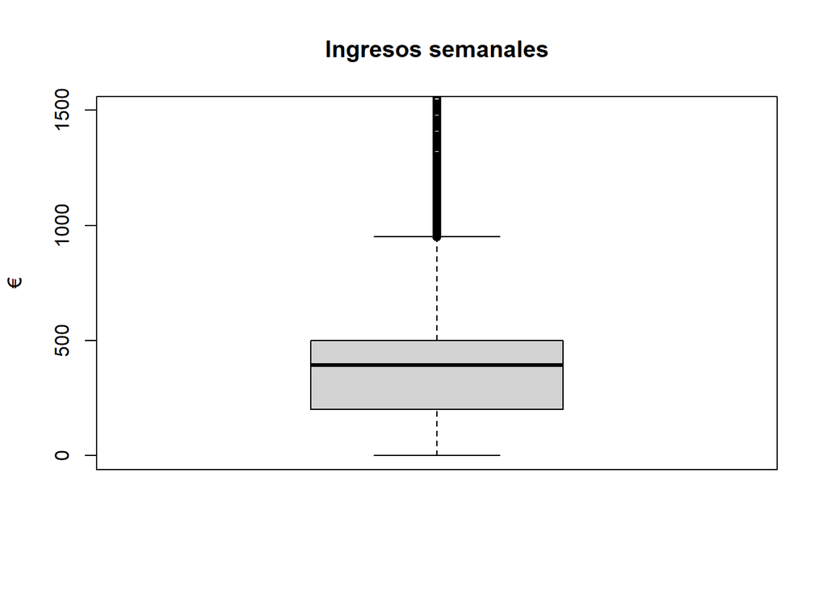

```r
boxplot(d$WeeklyWages, main="Ingresos semanales", ylab="€", breaks="FD", ylim=c(0, 1500))
```

La variable muestra una distribución asimétrica con la media en torno a los €400 y unos valores extremos que se extiende más allá del límite del gráfico hasta alcanzar el valor máximo de €7497.

##### *HoursWeek*

Tipo de variable, muestra y resumen:

```r
typeof(d$HoursWeek)
```

```
## [1] "character"
```

```r
head(d$HoursWeek)
```

```
## [1] "38"   "37,5" "38"   "38"   "38"   "38"
```

```r
tail(d$HoursWeek)
```

```
## [1] "40" "38" "40" "40" "38" "38"
```

```r
summary(d$HoursWeek)
```

```
##    Length     Class      Mode
##     54000 character character
```

Comprobamos que no hay valores vacíos ni nulos.

```r
length(which(is.na(d$HoursWeek))) + length(which(is.nan(d$HoursWeek))) + length(which(is.null(d$HoursWeek)))
```

```
## [1] 0
```

Como en el caso anterior, esta variable ha sido interpretada como de tipo *character* debido a las comas que separan los decimales. Por lo tanto, volvemos a usar la función *scan()* para reemplazar las comas por puntos y convertirla en tipo *double*.

```r
d$HoursWeek <- scan(text=d$HoursWeek, dec=",", sep=".")
```

```r
typeof(d$HoursWeek)
```

```
## [1] "double"
```

```r
head(d$HoursWeek)
```

```
## [1] 38.0 37.5 38.0 38.0 38.0 38.0
```

```r
tail(d$HoursWeek)
```

```
## [1] 40 38 40 40 38 38
```

```r
summary(d$HoursWeek)
```

```
##    Min. 1st Qu.  Median    Mean 3rd Qu.    Max.
##    0.00   38.00   38.00   37.74   40.00  640.00
```

Observamos que hay valores incongruentes (el máximo es 640, mientras que una semana tiene 168 horas). Esto lo trataremos más adelante.

Dibujamos el histograma para visualizar la distribución.

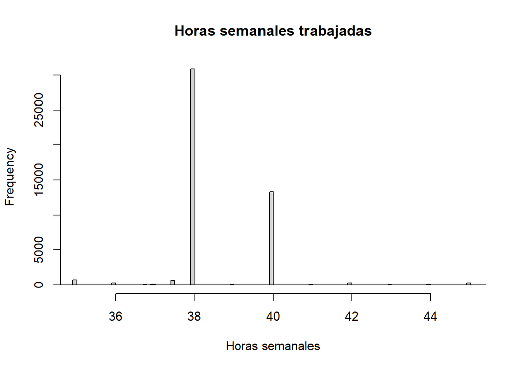

```r
hist(d$HoursWeek, main="Horas semanales trabajadas", xlab="Horas semanales", breaks="FD", xlim=c(35, 45))
```

La distribución presenta dos grandes acumulaciones en los valores de 38 y 40 horas semanales trabajadas.

##### *DaysWeek*

Tipo de variable, muestra y resumen:

```r
typeof(d$DaysWeek)
```

```
## [1] "integer"
```

```r
head(d$DaysWeek)
```

```
## [1] 5 5 5 5 5 5
```

```r
tail(d$DaysWeek)
```

```
## [1] 5 5 5 5 5 5
```

```r
summary(d$DaysWeek)
```

```
##    Min. 1st Qu.  Median    Mean 3rd Qu.    Max.
##   1.000   5.000   5.000   4.906   5.000   7.000
```

Comprobamos que no hay valores vacíos ni nulos.

```r
length(which(is.na(d$DaysWeek))) + length(which(is.nan(d$DaysWeek))) + length(which(is.null(d$DaysWeek)))
```

```
## [1] 0
```

Esta variable ya es de tipo *integer*, por lo que no es necesario realizar ninguna acción sobre la misma.

Dibujamos el histograma para visualizar la distribución.

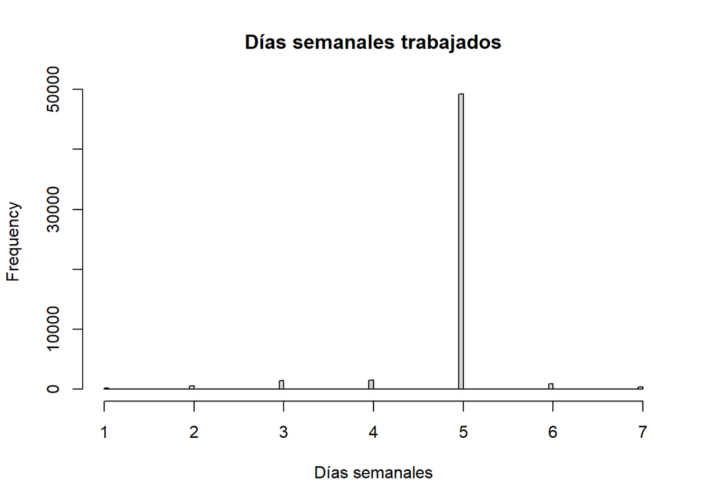

```r
hist(d$DaysWeek, main="Días semanales trabajados", xlab="Días semanales", breaks="FD", xlim=c(1, 7))
```

La distribución muestra que la mayoría de los registros del dataset trabajn 5 días a la semana.

### 6. Valores atípicos

##### *Age*

Como hemos visto anteriormente, hay 12 registros con un valor atípico (*999*) en esta variable.

```r
length(which(d$Age==999))
```

```
## [1] 12
```

Esto se debe a que, probablemente, la edad de estos registros es desconocida, por lo que se ha optado por poner dicho valor para representarlo.

Para solucionarlo, obtenemos los registros que muestran este valor y lo reemplazamos por *NA*.

```r
d$Age[which(d$Age==999)] <- NA
summary(d$Age)
```

```
##    Min. 1st Qu.  Median    Mean 3rd Qu.    Max.    NA's
##   13.00   23.00   32.00   33.84   43.00   81.00      12
```

Vemos ahora que el rango de valores es [13,81], lo que no representa ningún valor atípico.

##### *WeeklyWage*

```r
summary(d$WeeklyWages)
```

```
##    Min. 1st Qu.  Median    Mean 3rd Qu.    Max.
##     1.0   200.0   392.2   416.4   500.0  7497.0
```

El valor mínimo que toma esta variable es **1**, lo que podría no representar unos ingresos semanales reales. Por lo tanto, buscamos la frecuencia con la que aparece este valor en el dataset.

```r
length(which(d$WeeklyWages==1))
```

```
## [1] 122
```

Hay 122 registros con este valor en la variable *WeeklyWages*. Esto indica que, efectivamente, se trata de un valor desconocido. Para solucionarlo, buscamos estos registros y sustituimos el valor **1** por **NA**.

```r
d$WeeklyWages[which(d$WeeklyWages==1)] <- NA
summary(d$WeeklyWages)
```

```
##    Min. 1st Qu.  Median    Mean 3rd Qu.    Max.    NA's
##    1.91  200.00  393.00  417.31  500.00 7497.00     122
```

```r
length(which(d$WeeklyWages==1.91))
```

```
## [1] 1
```

Vemos ahora que el actual valor mínimo es **1.91*. Al darse solo una vez en todo el dataset, en este caso sí que representaría un valor real.

##### *HoursWeek*

```r
summary(d$HoursWeek)
```

```
##    Min. 1st Qu.  Median    Mean 3rd Qu.    Max.
##    0.00   38.00   38.00   37.74   40.00  640.00
```

Una semana tiene 168 horas. Por lo tanto, todos los valores superiores a 168 se deben a errores o registros vacíos.

Para subsanarlo, reemplazados dichos valores por *NA*.

```r
length(which(d$HoursWeek > 168))
```

```
## [1] 36
```

```r
d$HoursWeek[which(d$HoursWeek > 168)] <- NA
summary(d$HoursWeek)
```

```
##    Min. 1st Qu.  Median    Mean 3rd Qu.    Max.    NA's
##    0.00   38.00   38.00   37.47   40.00  168.00      36
```

Nos encontramos que todavía hay valores que podrían no ser reales (por algún motivo, un registro podría tener el máximo número de horas semanales posible -168- si, por ejemplo, su trabajo consiste en esta disponible 24x7, por lo que se podría considerarar que trabaja el 100% del tiempo). Para comprobarlo, vemos si *DaysWeek* es 7; de lo contrario, *HoursWeek* sería incongruente.

```r
length(which(d$HoursWeek == 168))
```

```
## [1] 1
```

Solo hay un registro con ese valor. Veamos el número de días que trabaja a la semana.

```r
d$DaysWeek[which(d$HoursWeek == 168)]
```

```
## [1] 5
```

Al ser menor que 7, el valor de la variable *HoursWeek* es incongruente, por lo que lo reemplazamos también por *NA*.

```r
d$HoursWeek[which(d$HoursWeek == 168)] <- NA
summary(d$HoursWeek)
```

```
##    Min. 1st Qu.  Median    Mean 3rd Qu.    Max.    NA's
##    0.00   38.00   38.00   37.47   40.00  100.00      37
```

En el siguiente apartado buscaremos si existen más incongruencias de este tipo entre las variables *HoursWeek* y *DaysWeek* (por ejemplo, una persona que trabaje 3 días a la semana y las horas semanales sean 90 -siendo 72 el máximo posible-).

##### *DaysWeek*

```r
summary(d$DaysWeek)
```

```
##    Min. 1st Qu.  Median    Mean 3rd Qu.    Max.
##   1.000   5.000   5.000   4.906   5.000   7.000
```

El rango de valores [1,7] es realista en esta variable.

Buscamos posibles incongruencias entre las variables *HoursWeek* y *DaysWeek*.

```r
length(which(d$HoursWeek > (d$DaysWeek*24)))
```

```
## [1] 17
```

Hay 17 valores cuyas horas semanales superan el máximo con respecto a los días semanales.

```r
d[which(d$HoursWeek > (d$DaysWeek*24)), c("HoursWeek", "DaysWeek")]
```

|  | HoursWeek | DaysWeek |
| --- | --- | --- |
| 2485 | 38 | 1 |
| 4416 | 38 | 1 |
| 6072 | 40 | 1 |
| 7238 | 71 | 2 |
| 11323 | 80 | 3 |
| 13374 | 25 | 1 |
| 22134 | 38 | 1 |
| 27952 | 38 | 1 |
| 35132 | 38 | 1 |
| 37304 | 38 | 1 |

[output cut: 7 more lines]

La mayoría de los registros tienen el valor mínimo de *DaysWeek*, mientras que las horas semanales se encuentran entre los valores más probables. Esto puede ser un indicativo de que los días semanales son desconcidos y se ha aplicado el valor mínimo para representarlo. Sin embargo, debido al alcance de este ejercicio, no vamos a reemplazar dichos valores de *DaysWeek* ya que eso implicaría tener que imputarlos posteriormente, y esto no está indicado en el enunciado.

Supongamos, exclusivamente para el siguiente razonamiento, que hemos reemplazado los valores anteriores de *DaysWeek* por *NA*.

```r
d[which(d$HoursWeek > (d$DaysWeek*24) & d$DaysWeek > 1), c("HoursWeek", "DaysWeek", "PartTimeFullTime")]
```

|  | HoursWeek | DaysWeek | PartTimeFullTime |
| --- | --- | --- | --- |
| 7238 | 71 | 2 | F |
| 11323 | 80 | 3 | F |
| 40812 | 83 | 3 | P |

Los 3 registros restantes tienen unos valores poco comunes en ambas variables (sin ser valores extremos), así que es difícil discernir dónde se encuentra el error. Sin embargo, al comparar con la variable *PartTimeFullTime*, vemos que en el caso del registro con *83* horas semanales y *3* días semanales también trabaja media jornada, lo que podría indicar que la variable errónea de este registro es *HoursWeek*. Sin embargo, suponiendo que el dato de media jornada sea correcto, las horas semanales no superarían el máximo posible (12 x 7 = 84). Por lo tanto, con los datos disponibles no podemos decidir qúe variable errónea, así que no los modificamos.

### 7. Imputación de valores

##### *Age*

Obtenemos el índice de los valores *NA*:

```r
which(is.na(d$Age))
```

```
##  [1]  5218  6850  7495 11184 17520 24946 28599 40524 47686 49006 51660 52964
```

Los reeplazamos por la media aritmética de la variable:

```r
d$Age[which(is.na(d$Age))] <- mean(d$Age[which(!is.na(d$Age))])
d$Age <- as.integer(d$Age)
```

#### Imputación *KNN*

Dividimos los registros por género, escogiendo las variables sobre las que se calculará la distancia en *KNN*:

```r
f <- d[which(d$Gender=="F"), c("WeeklyWages", "HoursWeek", "IniCost", "UltCost")]
m <- d[which(d$Gender=="M"), c("WeeklyWages", "HoursWeek", "IniCost", "UltCost")]
u <- d[which(d$Gender=="U"), c("WeeklyWages", "HoursWeek", "IniCost", "UltCost")]
```

##### *WeeklyWages*

Registros a imputar de género F:

```r
length(which(is.na(f$WeeklyWages)))
```

```
## [1] 32
```

Registros a imputar de género M:

```r
length(which(is.na(m$WeeklyWages)))
```

```
## [1] 90
```

Registros a imputar de género U:

```r
length(which(is.na(u$WeeklyWages)))
```

```
## [1] 0
```

Imputamos los registros de género *F*:

```r
f_imp <- kNN(f, variable = "WeeklyWages")
summary(f_imp)
```

```
##   WeeklyWages        HoursWeek         IniCost          UltCost
##  Min.   :   1.91   Min.   :  0.00   Min.   :     1   Min.   :     29
##  1st Qu.: 200.00   1st Qu.: 32.71   1st Qu.:  1000   1st Qu.:   1577
##  Median : 345.42   Median : 38.00   Median :  3500   Median :   4068
##  Mean   : 368.60   Mean   : 34.50   Mean   :  9000   Mean   :  11781
##  3rd Qu.: 491.79   3rd Qu.: 38.00   3rd Qu.: 10000   3rd Qu.:  10862
##  Max.   :7497.00   Max.   :100.00   Max.   :872980   Max.   :1570535
##                    NA's   :10
##  WeeklyWages_imp
##  Mode :logical
##  FALSE:12306
##  TRUE :32
##
##
##
##
```

Imputamos los registros de género *M*:

```r
m_imp <- kNN(m, variable = "WeeklyWages")
summary(m_imp)
```

```
##   WeeklyWages        HoursWeek        IniCost             UltCost
##  Min.   :   3.95   Min.   : 0.00   Min.   :      1.0   Min.   :      5
##  1st Qu.: 200.00   1st Qu.:38.00   1st Qu.:    613.2   1st Qu.:   1031
##  Median : 408.50   Median :38.00   Median :   2000.0   Median :   2933
##  Mean   : 431.52   Mean   :38.35   Mean   :   7498.2   Mean   :   9726
##  3rd Qu.: 520.98   3rd Qu.:40.00   3rd Qu.:   8200.0   3rd Qu.:   8344
##  Max.   :7497.00   Max.   :93.00   Max.   :2000000.0   Max.   :1423207
##                    NA's   :27
##  WeeklyWages_imp
##  Mode :logical
##  FALSE:41570
##  TRUE :90
##
##
##
##
```

Cargamos en el dataset original los valores imputados

```r
d$WeeklyWages[which(is.na(d$WeeklyWages) & d$Gender == "F")] <- f_imp$WeeklyWages[which(f_imp$WeeklyWages_imp)]
d$WeeklyWages[which(is.na(d$WeeklyWages) & d$Gender == "M")] <- m_imp$WeeklyWages[which(m_imp$WeeklyWages_imp)]
```

Valores imputados de género *F*:

```r
d$WeeklyWages[which(is.na(f$WeeklyWages))]
```

```
##  [1] 550.00 200.00 371.60 251.64 577.70 200.00 541.37 293.40 620.00 605.87
## [11] 458.62 963.30 852.52 465.87 200.00 200.00 469.19 522.20 500.00 309.80
## [21] 400.00 459.00 200.00 200.00 200.00 684.00 200.00 200.00 379.63 215.00
## [31] 356.73 570.96
```

Valores imputados de género *M*:

```r
d$WeeklyWages[which(is.na(m$WeeklyWages))]
```

```
##  [1]  200.00  200.00  200.00  474.00  442.00  209.20  200.00  643.75  672.91
## [10]  497.15  166.95  350.00  234.00  122.11  200.00  497.84 1592.31  418.75
## [19]  423.20 1074.00  500.00  576.00  365.90  456.00  250.00  857.60  420.00
## [28]  200.00  635.00  507.20  332.00  200.00  488.00  490.00  200.00  656.00
## [37]  699.40  500.00  200.00  343.29  500.00  200.00  358.65  868.36  427.68
## [46]  666.71  500.00  200.00  200.00  593.00  127.12  393.80  640.00  200.00
## [55]  235.50  386.20  409.60  200.00  450.00  734.00  200.00  200.00  200.00
## [64]  100.00  500.00  484.50  184.74  200.00  200.00  412.00  676.00  700.00
## [73]  785.40  561.60  542.95  401.30  977.80  101.65  448.40  200.00  488.46
## [82]  277.40  629.80  493.85  774.62  200.00  200.00  504.59  313.89  500.00
```

##### *HoursWeek*

Registros a imputar de género F:

```r
length(which(is.na(f$HoursWeek)))
```

```
## [1] 10
```

Registros a imputar de género M:

```r
length(which(is.na(m$HoursWeek)))
```

```
## [1] 27
```

Registros a imputar de género U:

```r
length(which(is.na(u$HoursWeek)))
```

```
## [1] 0
```

Imputamos los registros de género *F*:

```r
f_imp <- kNN(f, variable = "HoursWeek")
summary(f_imp)
```

```
##   WeeklyWages        HoursWeek         IniCost          UltCost
##  Min.   :   1.91   Min.   :  0.00   Min.   :     1   Min.   :     29
##  1st Qu.: 200.00   1st Qu.: 32.81   1st Qu.:  1000   1st Qu.:   1577
##  Median : 345.33   Median : 38.00   Median :  3500   Median :   4068
##  Mean   : 368.66   Mean   : 34.50   Mean   :  9000   Mean   :  11781
##  3rd Qu.: 492.07   3rd Qu.: 38.00   3rd Qu.: 10000   3rd Qu.:  10862
##  Max.   :7497.00   Max.   :100.00   Max.   :872980   Max.   :1570535
##  NA's   :32
##  HoursWeek_imp
##  Mode :logical
##  FALSE:12328
##  TRUE :10
##
##
##
##
```

Imputamos los registros de género *M*:

```r
m_imp <- kNN(m, variable = "HoursWeek")
summary(m_imp)
```

```
##   WeeklyWages        HoursWeek        IniCost             UltCost
##  Min.   :   3.95   Min.   : 0.00   Min.   :      1.0   Min.   :      5
##  1st Qu.: 200.00   1st Qu.:38.00   1st Qu.:    613.2   1st Qu.:   1031
##  Median : 408.90   Median :38.00   Median :   2000.0   Median :   2933
##  Mean   : 431.70   Mean   :38.35   Mean   :   7498.2   Mean   :   9726
##  3rd Qu.: 521.00   3rd Qu.:40.00   3rd Qu.:   8200.0   3rd Qu.:   8344
##  Max.   :7497.00   Max.   :93.00   Max.   :2000000.0   Max.   :1423207
##  NA's   :90
##  HoursWeek_imp
##  Mode :logical
##  FALSE:41633
##  TRUE :27
##
##
##
##
```

Cargamos en el dataset original los valores imputados

```r
d$HoursWeek[which(is.na(d$HoursWeek) & d$Gender == "F")] <- f_imp$HoursWeek[which(f_imp$HoursWeek_imp)]
d$HoursWeek[which(is.na(d$HoursWeek) & d$Gender == "M")] <- m_imp$HoursWeek[which(m_imp$HoursWeek_imp)]
```

Valores imputados de género *F*:

```r
d$HoursWeek[which(is.na(f$HoursWeek))]
```

```
##  [1] 40 40 56 38 40 38 40 38 40 40
```

Valores imputados de género *M*:

```r
d$HoursWeek[which(is.na(m$HoursWeek))]
```

```
##  [1] 38.0 24.0 40.0 25.0 42.2 38.0 12.0 25.0 38.0 29.0 40.0 40.0 40.0 40.0 38.0
## [16] 30.0 38.0 38.0 38.0 40.0 38.0 38.0 38.0 40.0 40.0 38.0 38.0
```

##### *IniCost*

Registros a imputar de género F:

```r
length(which(is.na(f$IniCost)))
```

```
## [1] 0
```

Registros a imputar de género M:

```r
length(which(is.na(m$IniCost)))
```

```
## [1] 0
```

Registros a imputar de género U:

```r
length(which(is.na(u$IniCost)))
```

```
## [1] 0
```

No hay registros vacíos, por lo que no hay nada que imputar.

##### *UltCost*

Registros a imputar de género F:

```r
length(which(is.na(f$UltCost)))
```

```
## [1] 0
```

Registros a imputar de género M:

```r
length(which(is.na(m$UltCost)))
```

```
## [1] 0
```

Registros a imputar de género U:

```r
length(which(is.na(u$UltCost)))
```

```
## [1] 0
```

No hay registros vacíos, por lo que no hay nada que imputar.

### 8. Preparación de los datos

#### 8.1. Tiempo de apertura del expediente

##### *DateTimeOfAccident*

```r
typeof(d$DateTimeOfAccident)
```

```
## [1] "character"
```

La variable es de tipo *character*, por lo que la convertimos en tipo *DateTime*.

```r
d$DateTimeOfAccident <- as.Date(d$DateTimeOfAccident)
head(d$DateTimeOfAccident)
```

```
## [1] "2002-04-09" "1999-01-07" "1996-03-25" "2005-06-22" "1990-08-29"
## [6] "1999-06-21"
```

##### *DateReported*

```r
typeof(d$DateReported)
```

```
## [1] "character"
```

La variable es de tipo *character*, por lo que la convertimos en tipo *DateTime*.

```r
d$DateReported <- as.Date(d$DateReported)
head(d$DateReported)
```

```
## [1] "2002-07-05" "1999-01-20" "1996-04-14" "2005-07-22" "1990-09-27"
## [6] "1999-09-09"
```

##### *Time*

Creamos una nueva variable que almacene la diferencia de tiempo entre *DateTimeOfAccident* y *DateReported*:

```r
Time <- d$DateReported -d$DateTimeOfAccident
Time <- as.integer(Time)
head(Time)
```

```
## [1] 87 13 20 30 29 80
```

Añadimos la nueva variable al conjunto de datos:

```r
d$Time <- Time
```

#### 8.2. Diferencia entre *IniCost* y *UltCost*

Creamos una nueva variable para almacenar la diferencia entre *IniCost* y *UltCost*:

```r
DifCost <- d$UltCost - d$IniCost
head(DifCost)
```

```
## [1] 2803  605  398 1282  971  246
```

Añadimos la nueva variable al conjunto de datos:

```r
d$DifCost <- DifCost
```

Distribución de la nueva variable:

```r
summary(d$DifCost)
```

```
##     Min.  1st Qu.   Median     Mean  3rd Qu.     Max.
## -1933783     -449      190     2354     1435  1527535
```

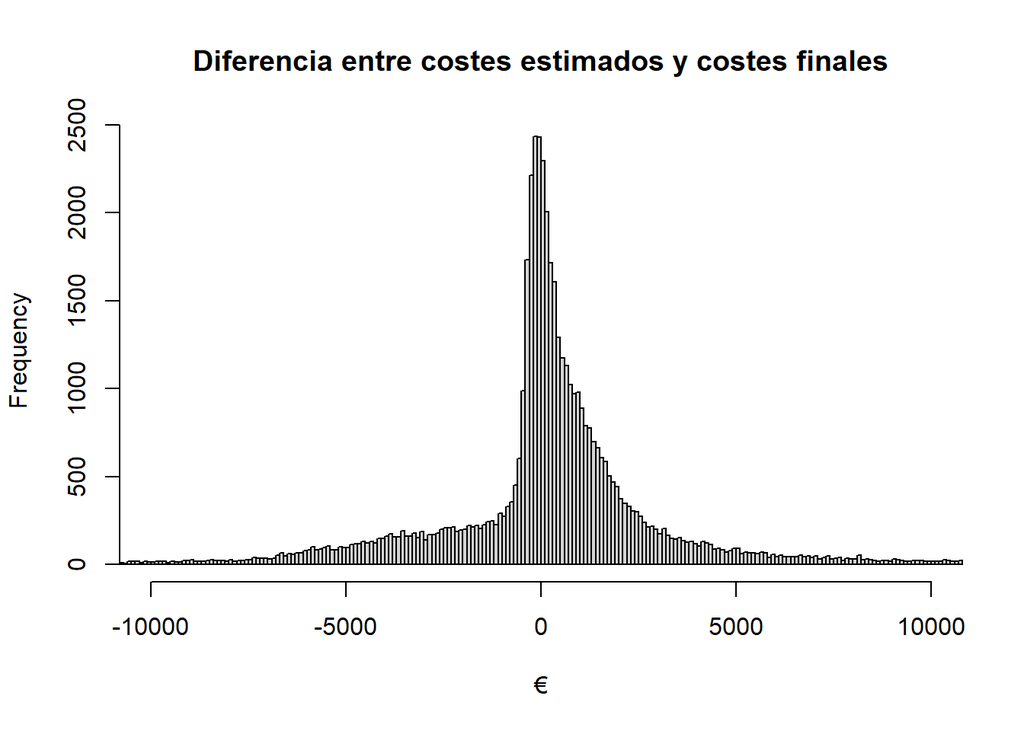

```r
hist(d$DifCost, main="Diferencia entre costes estimados y costes finales", xlab="€", breaks="FD", xlim=c(-10000, 10000))
```

En este histograma observamos que la distribución tiene valores muy extremos a ambos lados, mientras que la mayor agrupación se sitúa en el centro de la distribución.

### 9. Estudio previo

#### 9.1. Funciones de media robustas

Función **media.recortada**:

```r
media.recortada <- function( x, perc=0.05){
  x <- sort(x)
  for (i in c(1:(perc*length(x)))){
    if (length(x) > 2){
      x <- x[2:(length(x)-1)]
    }
    else{
      break
    }
  }
  return (mean(x))
}
```

Función **media.winsor**:

```r
media.winsor <- function( x, perc=0.05){
  x <- sort(x)
  for (i in c(1:(perc*length(x)))){
    if (length(x) > 2){
      x <- replace(x, i, x[i+1])
      x <- replace(x, length(x)-i+1, x[length(x)-i])
    }
    else{
      break
    }
  }
  return (mean(x))
}
```

Comprobamos que ambas funciones correctamente. Para ello, tomamos el vector **(-1, 0, 1, 2, 3, 4, 5, 6, 7, 8, 9, 50, 100)**, cuya media es:

```r
v <- c(-1, 0, 1, 2, 3, 4, 5, 6, 7, 8, 9, 50, 100)
mean(v)
```

```
## [1] 14.92308
```

La media recortada al 10% debería ser igual a la media del vector **(0, 1, 2, 3, 4, 5, 6, 7, 8, 9, 50)**, ya que se eliminan los valores extremos (-1 y 100).

```r
media.recortada(v, perc=0.1)
```

```
## [1] 8.636364
```

```r
mean(c(0, 1, 2, 3, 4, 5, 6, 7, 8, 9, 50))
```

```
## [1] 8.636364
```

La media winsorizada al 10% debería ser igual a la media del vector **(0, 0, 1, 2, 3, 4, 5, 6, 7, 8, 9, 50, 50)**, ya que los valores extremos (-1 y 100) se sutituyen por los valores más cercanos respectivamente (0 y 50).

```r
media.winsor(v, perc=0.1)
```

```
## [1] 11.15385
```

```r
mean(c(0, 0, 1, 2, 3, 4, 5, 6, 7, 8, 9, 50, 50))
```

```
## [1] 11.15385
```

Ambas funciones devuelven el resultado esperado.

#### 9.2. Estudio descriptivo de las variables cuantitativas

Creamos un *dataframe* con las variables **Mínimo**, **PrimerCuartil**, **Mediana**, **Media**, **TercerCuartil**, **Maximo**, **DesviacionEstandar**, **MediaRecortada5**, **MediaRecortada10**, **MediaRecortada20**, **MediaWinsorizada5**, **MediaWinsorizada10** y **MediaWinsorizada20**. Las calculamos para cada una de las variables del conjunto de datos a analizar y mostramos el resultado:

```r
analisis <- data.frame(

Minimo = c(min(d$Age), min(d$WeeklyWages), min(d$DaysWeek), min(d$HoursWeek), min(d$IniCost), min(d$UltCost)),

PrimerCuartil = c(summary(d$Age)[2], summary(d$WeeklyWages)[2], summary(d$DaysWeek)[2], summary(d$HoursWeek)[2], summary(d$IniCost)[2], summary(d$UltCost)[2]),

Mediana = c(summary(d$Age)[3], summary(d$WeeklyWages)[3], summary(d$DaysWeek)[3], summary(d$HoursWeek)[3], summary(d$IniCost)[3], summary(d$UltCost)[3]),

Media = c(mean(d$Age), mean(d$WeeklyWages), mean(d$DaysWeek), mean(d$HoursWeek), mean(d$IniCost), mean(d$UltCost)),

TercerCuartil = c(summary(d$Age)[5], summary(d$WeeklyWages)[5], summary(d$DaysWeek)[5], summary(d$HoursWeek)[5], summary(d$IniCost)[5], summary(d$UltCost)[5]),

Maximo = c(max(d$Age), max(d$WeeklyWages), max(d$DaysWeek), max(d$HoursWeek), max(d$IniCost), max(d$UltCost)),

DesviacionEstandar = c(sd(d$Age), sd(d$WeeklyWages), sd(d$DaysWeek), sd(d$HoursWeek), sd(d$IniCost), sd(d$UltCost)),

MediaRecortada5 = c(media.recortada(d$Age, perc=0.05), media.recortada(d$WeeklyWages, perc=0.05), media.recortada(d$DaysWeek, perc=0.05), media.recortada(d$HoursWeek, perc=0.05), media.recortada(d$IniCost, perc=0.05), media.recortada(d$UltCost, perc=0.05)),

MediaRecortada10 = c(media.recortada(d$Age, perc=0.1), media.recortada(d$WeeklyWages, perc=0.1), media.recortada(d$DaysWeek, perc=0.1), media.recortada(d$HoursWeek, perc=0.1), media.recortada(d$IniCost, perc=0.1), media.recortada(d$UltCost, perc=0.1)),

MediaRecortada20 = c(media.recortada(d$Age, perc=0.2), media.recortada(d$WeeklyWages, perc=0.2), media.recortada(d$DaysWeek, perc=0.2), media.recortada(d$HoursWeek, perc=0.2), media.recortada(d$IniCost, perc=0.2), media.recortada(d$UltCost, perc=0.2)),

MediaWinsorizada5 = c(media.winsor(d$Age, perc=0.05), media.winsor(d$WeeklyWages, perc=0.05), media.winsor(d$DaysWeek, perc=0.05), media.winsor(d$HoursWeek, perc=0.05), media.winsor(d$IniCost, perc=0.05), media.winsor(d$UltCost, perc=0.05)),

MediaWinsorizada10 = c(media.winsor(d$Age, perc=0.1), media.winsor(d$WeeklyWages, perc=0.1), media.winsor(d$DaysWeek, perc=0.1), media.winsor(d$HoursWeek, perc=0.1), media.winsor(d$IniCost, perc=0.1), media.winsor(d$UltCost, perc=0.1)),

MediaWinsorizada20 = c(media.winsor(d$Age, perc=0.2), media.winsor(d$WeeklyWages, perc=0.2), media.winsor(d$DaysWeek, perc=0.2), media.winsor(d$HoursWeek, perc=0.2), media.winsor(d$IniCost, perc=0.2), media.winsor(d$UltCost, perc=0.2))

)

rownames(analisis) <- c("Age", "WeeklyWages", "DaysWeek", "HoursWeek", "IniCost", "UltCost")

analisis
```

|  | Minimo | PrimerCuartil | Mediana | Media | TercerCuartil | Maximo | DesviacionEstandar | MediaRecortada5 | MediaRecortada10 | MediaRecortada20 | MediaWinsorizada5 | MediaWinsorizada10 | MediaWinsorizada20 |
| --- | --- | --- | --- | --- | --- | --- | --- | --- | --- | --- | --- | --- | --- |
| Age | 13.00 | 23 | 32 | 33.841426 | 43 | 81 | 1.212035e+01 | 33.317181 | 32.95502 | 32.43719 | 33.841056 | 33.841000 | 33.840926 |
| WeeklyWages | 1.91 | 200 | 393 | 417.141490 | 500 | 7497 | 2.479869e+02 | 395.003068 | 385.55449 | 379.35349 | 417.021457 | 417.018947 | 417.016482 |
| DaysWeek | 1.00 | 5 | 5 | 4.905759 | 5 | 7 | 5.521291e-01 | 4.981317 | 5.00000 | 5.00000 | 4.905778 | 4.905796 | 4.905796 |
| HoursWeek | 0.00 | 38 | 38 | 37.472396 | 40 | 100 | 7.007433e+00 | 37.941636 | 38.40170 | 38.30701 | 37.471699 | 37.471923 | 37.471988 |
| IniCost | 1.00 | 700 | 2000 | 7841.146019 | 9500 | 2000000 | 2.058408e+04 | 5102.874218 | 4226.09076 | 3450.27454 | 7804.670352 | 7804.460815 | 7804.303407 |
| UltCost | 5.00 | 1128 | 3179 | 10194.961981 | 8900 | 1570535 | 2.902351e+04 | 6195.800885 | 5109.90306 | 4037.47130 | 10166.604556 | 10166.305685 | 10166.107130 |

Representación gráfica de las variables analizadas:

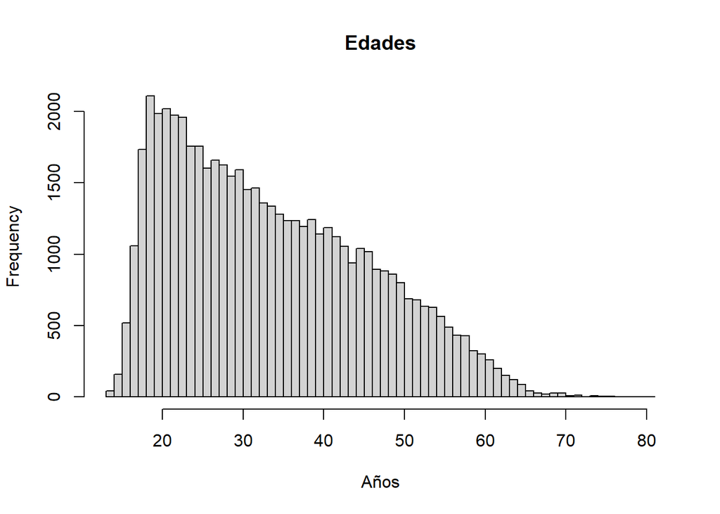

```r
hist(d$Age, main="Edades", xlab="Años", breaks="FD", xlim=c(13, 81))
```

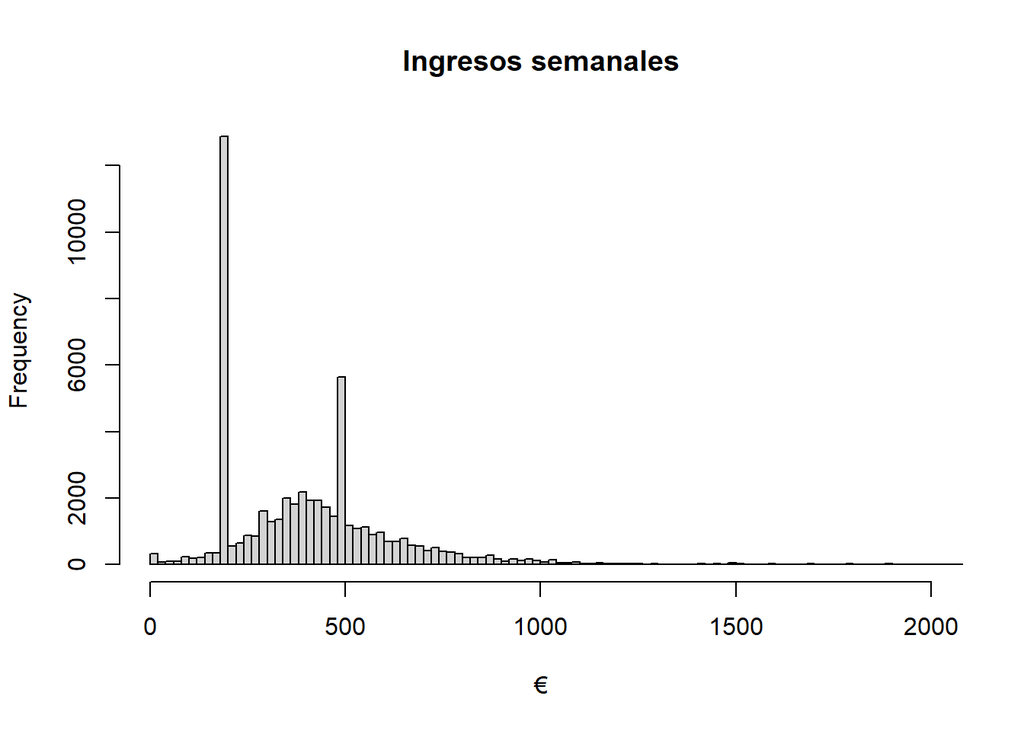

```r
hist(d$WeeklyWages, main="Ingresos semanales", xlab="€", breaks="FD", xlim=c(2, 2000))
```

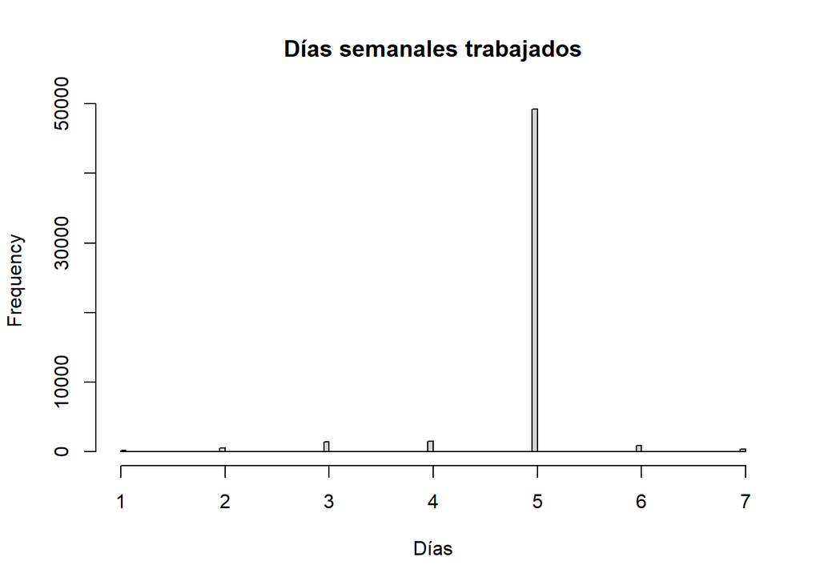

```r
hist(d$DaysWeek, main="Días semanales trabajados", xlab="Días", breaks="FD", xlim=c(1, 7))
```

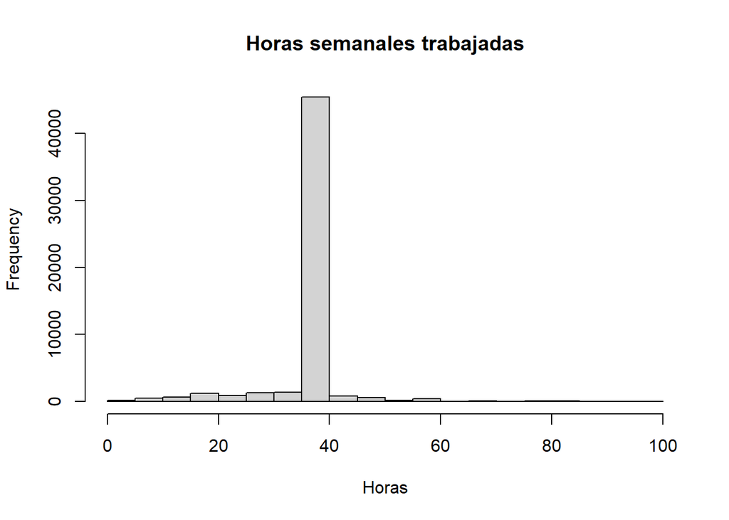

```r
hist(d$HoursWeek, main="Horas semanales trabajadas", xlab="Horas", xlim=c(0, 100))
```

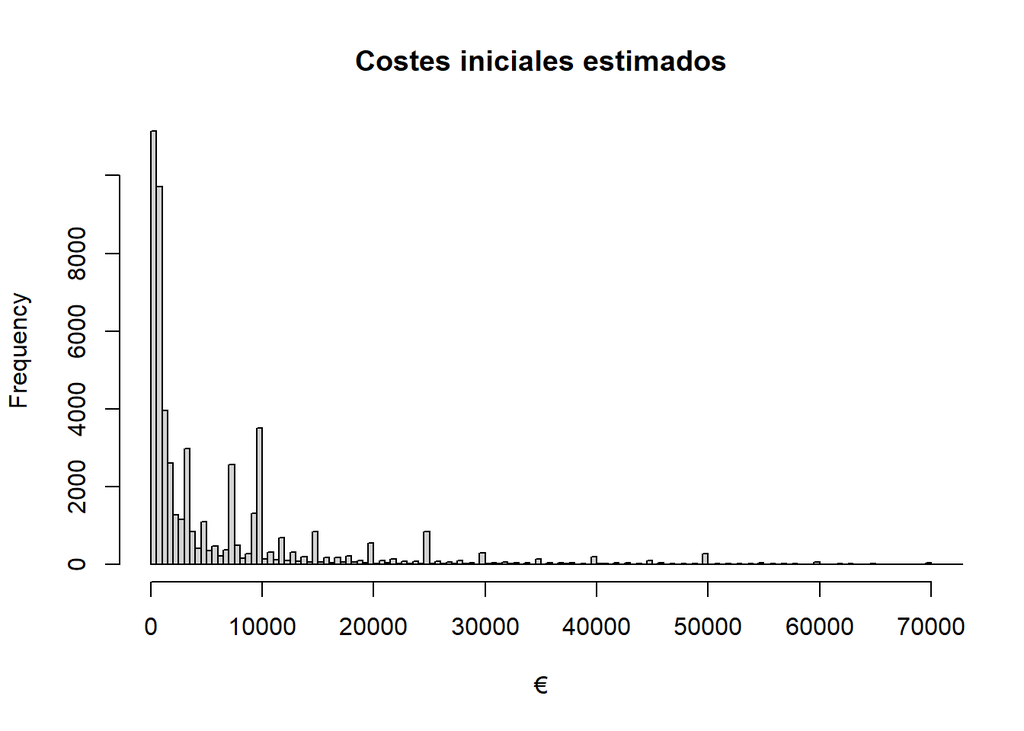

```r
hist(d$IniCost, main="Costes iniciales estimados", xlab="€", breaks="FD", xlim=c(1, 70000), ylim=c(0, 11000))
```

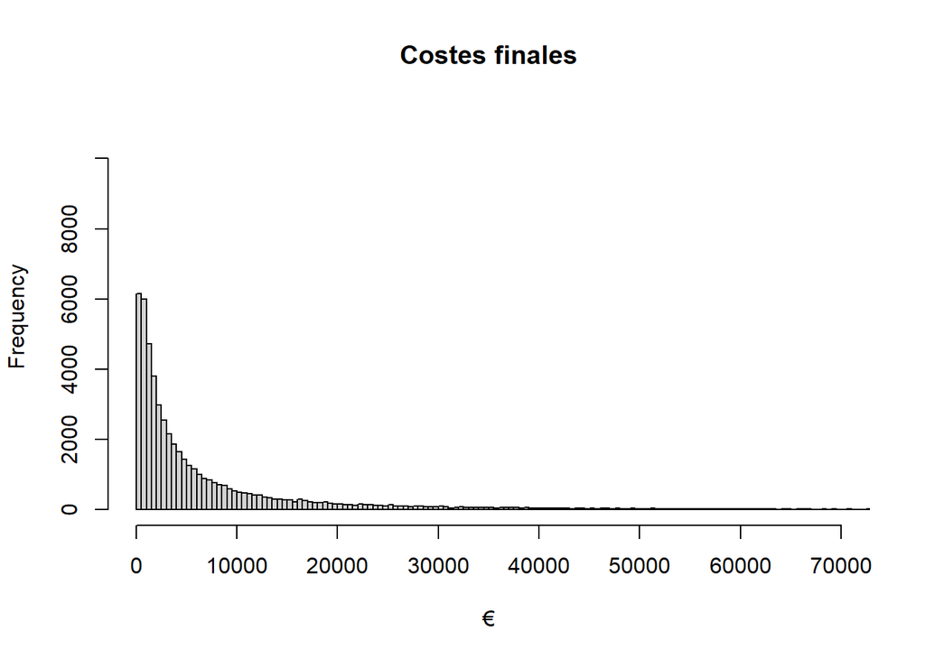

```r
hist(d$UltCost, main="Costes finales", xlab="€", breaks="FD", xlim=c(1, 70000), ylim=c(0, 11000))
```

### 9. Archivo final

Exportamos los datos trabajados a un archivo csv:

```r
write.csv(d,"train_clean.csv", row.names = FALSE)
```